# Monte Carlo Testing: Additional Examples

## Example: hot hands

For the next example, let’s do something slightly more complicated.

A certain professional basketball player believes he has “[hot hands](https://en.wikipedia.org/wiki/Hot_hand)” when shooting 3-point shots (i.e. if he makes a shot, he’s more likely to also make the next shot). His friend doesn’t believe him, so they make a wager and hire you, a statistician, to settle the bet.

As a sample, you observe the next morning as the player takes the same 3-point shot 200 times in a row (assume he is well rested, in good physical shape, and doesn’t feel significantly more tired after the experiment), so his level of mental focus doesn’t change during the experiment). You obtain the following results, where Y denotes a success and N denotes a miss:

```
YNNNNYYNNNYNNNYYYNNNNNYNNNNNNNNNYNNNNNYYNYYNNNYNNNNYNNYYYYNNYY
NNNNNNNNNNNNNNNYYYNNNYYYYNNNNNYNYYNNNNYNNNNNNYNNNYNNYNNNNNYNYY
YNNYYYNYNNNNYNNNNNNNYYNNYYNNNNNNYNNNYNNNNNNNNYNNNYNNNNNYYNNNNN
NYYYYYYNYYNNYN
```

The hypotheses being tested are: $H_0:$ there is no hot hand effect - shots are independent $H_A:$ there is some dependency between shots

Note that the existence of a “hot hands” effect means the shots are not independent. Also note that there’s a third possibility: that the player is more likely to “choke” and miss the next shot if he scored the previous one (e.g. maybe scoring a shot makes him feel more nervous because he feels like he’s under pressure).

### Attempt 1: run length

Since the existence of a hot hands effect tends to increase the run lengths of `Y`s compared to if the shots were independent, we can use the longest run length as a way of comparing independence vs hot hands (note if the player is a choker, they will tend to have shorter runs of `Y`s than if they were independent, so you can simply ignore this case for now and compare hot hands v. independence for simplicity).

Now, how exactly do you compare these two situations and determine which is a better fit for the data?

One thing that’s worth noting is that *if a sequence of repeated experiments is independent, then it shouldn’t matter what order the results are in*. This should be fairly easy to understand and agree with.

Let’s *assume that the throws are totally independent*. Recall we also assume he doesn’t get tired so his baseline shot-making ability doesn’t change over the course of the experiment. Therefore, we should be able to (under these assumptions) *arbitrarily reorder his shots without affecting any statistical properties of his shot sequence*. So let’s do that!

We begin by parsing the throws into a vector of `Y` and `N`.

```r
# the sequence of throws is broken up into 4 chunks for readability, then
# paste0 is used to merge them into a single sequence, then
# strplit("YN...N",split="") is used to split the string at every "", so
# we get a vector of each character, and finally
# [[1]] is used to get the vector itself (strsplit actually outputs a list
# with the vector as the first element; [[1]] removes the list wrapper)
#
# for more info about the strsplit function, see
# https://www.journaldev.com/43001/strsplit-function-in-r

throws = strsplit(
   paste0("YNNNNYYNNNYNNNYYYNNNNNYNNNNNNNNNYNNNNNYYNYYNNNYNNN",
          "NYNNYYYYNNYYNNNNNNNNNNNNNNNYYYNNNYYYYNNNNNYNYYNNNN",
          "YNNNNNNYNNNYNNYNNNNNYNYYYNNYYYNYNNNNYNNNNNNNYYNNYY",
          "NNNNNNYNNNYNNNNNNNNYNNNYNNNNNYYNNNNNNYYYYYYNYYNNYN"), split="")[[1]]

throws
```

```
##   [1] "Y" "N" "N" "N" "N" "Y" "Y" "N" "N" "N" "Y" "N" "N" "N" "Y" "Y" "Y" "N"
##  [19] "N" "N" "N" "N" "Y" "N" "N" "N" "N" "N" "N" "N" "N" "N" "Y" "N" "N" "N"
##  [37] "N" "N" "Y" "Y" "N" "Y" "Y" "N" "N" "N" "Y" "N" "N" "N" "N" "Y" "N" "N"
##  [55] "Y" "Y" "Y" "Y" "N" "N" "Y" "Y" "N" "N" "N" "N" "N" "N" "N" "N" "N" "N"
##  [73] "N" "N" "N" "N" "N" "Y" "Y" "Y" "N" "N" "N" "Y" "Y" "Y" "Y" "N" "N" "N"
##  [91] "N" "N" "Y" "N" "Y" "Y" "N" "N" "N" "N" "Y" "N" "N" "N" "N" "N" "N" "Y"
## [109] "N" "N" "N" "Y" "N" "N" "Y" "N" "N" "N" "N" "N" "Y" "N" "Y" "Y" "Y" "N"
## [127] "N" "Y" "Y" "Y" "N" "Y" "N" "N" "N" "N" "Y" "N" "N" "N" "N" "N" "N" "N"
## [145] "Y" "Y" "N" "N" "Y" "Y" "N" "N" "N" "N" "N" "N" "Y" "N" "N" "N" "Y" "N"
## [163] "N" "N" "N" "N" "N" "N" "N" "Y" "N" "N" "N" "Y" "N" "N" "N" "N" "N" "Y"
## [181] "Y" "N" "N" "N" "N" "N" "N" "Y" "Y" "Y" "Y" "Y" "Y" "N" "Y" "Y" "N" "N"
## [199] "Y" "N"
```

Next, we write a function to get the longest run of `Y`s in the throw sequence. Here we use a convenient function called `rle( )` which is short for [run length encoding](https://en.wikipedia.org/wiki/Run-length_encoding), which turns our sequence of throws into sequences of runs (e.g. YNNNNYYNNNY becomes something like “1 `Y`, 4 `N`s, 2 `Y`s, 3 `N`s, and 1 `Y`”). We can then simply take the longest of the `Y` runs.

```r
longestRun = function(x, target = 'Y'){
    max(0, with(rle(x), lengths[values==target]))
}

longestRun(throws)
```

```
## [1] 6
```

Now, we randomly shuffle the sequence of throws many times and see what the longest `Y` runs look like for these shuffled sequences.

```r
# set number of reps to use
MCN = 10000

# create vector to save results in
mc.runs = rep(0,MCN)

# for each rep, randomize sequence and find longest run of Y
for(i in 1:MCN){
    mc.runs[i] = longestRun(sample(throws))
}
```

```r
options(max.print=50)
mc.runs
```

```
##  [1] 4 4 6 5 6 3 4 4 5 6 4 4 3 3 4 3 5 5 4 3 4 6 5 4 3 5 4 4 4 3 4 4 4 4 6 4 5 5
## [39] 5 6 4 5 3 6 6 8 4 4 5 6
##  [ reached getOption("max.print") -- omitted 9950 entries ]
```

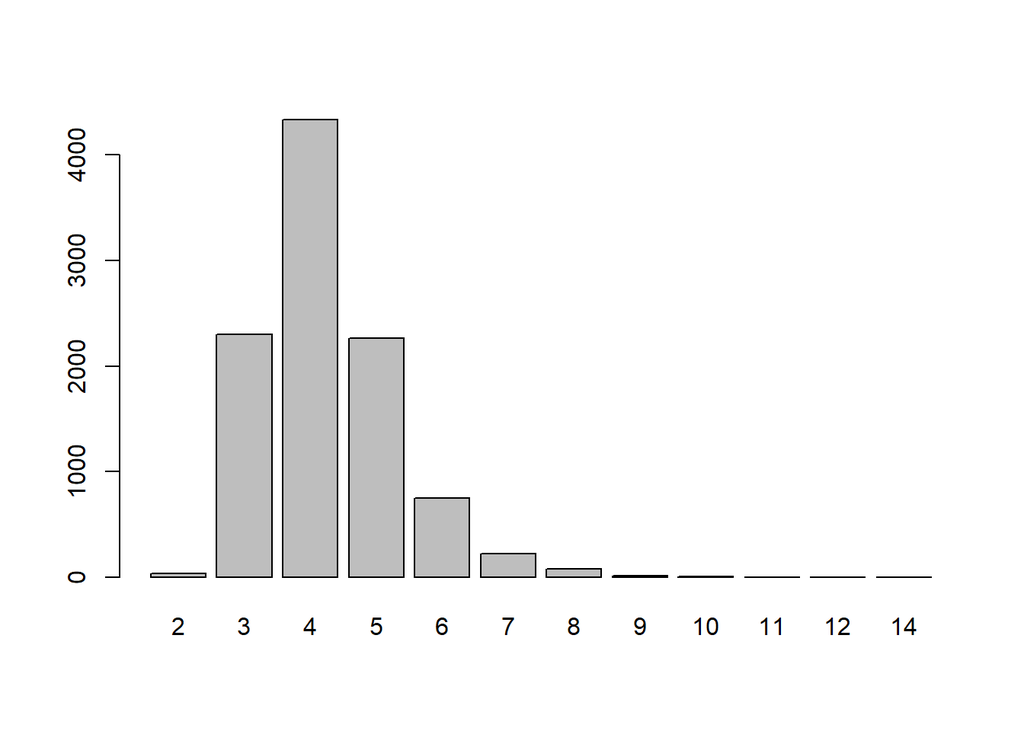

```r
barplot(table(mc.runs))
```

For a two tailed test - if you would reject the null hypothesis if the test statistic lived in either the upper or the lower tail of the distribution, a general rule to use is to take the proportion >= observed and <= observed, whichever one is smaller, double that.

```r
mean(mc.runs >= 6) * 2 #because it's a 2 tailed test
```

```
## [1] 0.2128
```

Compared to other shuffled sequences, our run length doesn’t seem that unlikely. Therefore, this method seems inconclusive.

Can we find an even better “statistic” to use?

### Attempt 2: running odds ratio

Consider **every pair of consecutive throws** and make a table of the outcomes. For example, the first 8 throws in the sequence are YNNNNYYN. Breaking this into consecutive pairs, we have YN, NN, NN, NN, NY, YY, YN. This gives the table:

| NN | NY | YN | YY |
| --- | --- | --- | --- |
| 3 | 1 | 2 | 1 |

Suppose we do this for the entire sequence of 200 throws (note this gives you 199 pairs). If we **divide the number of NY by the number of NN**, we get an estimate for **how much *more* likely he is to make the next shot *assuming he missed his last shot***.

Similarly, we can **divide the number of YY by the number of YN** to get an estimate for **how much *more* likely he is to make the next shot *assuming he scored his last shot***.

Now, note that **if the “hot hands” effect really exists** in the data, then **YY/YN should be larger than NY/NN** in a large enough sample. We use this fact to define the following quantity:

$$R=\frac{(\text{# of YY})/(\text{# of YN})}{(\text{# of NY})/(\text{# of
NN})}$$

The ratio $R$ represents, in some sense, **how much more likely** the player is to **make the next shot** if he **made the previous shot *vs* if he didn’t make the previous shot** (note the *vs*). This is exactly what we’re trying to investigate!

If there is a “hot hands” effect, the numerator should be greater than the denominator and we should have $R>1$. If the throws are independent and do not affect each other then in theory we should have $R=1$. If the player is actually a choker (i.e. he is more likely to miss after a successful shot), then we should have $R<1$. (Side note: this is basically an [odds ratio](https://journalfeed.org/article-a-day/2018/idiots-guide-to-odds-ratios)).

Now, we can use the same general method as the first attempt. If we assume his throws are independent and his shot probability doesn’t change significantly during the experiment, then we can randomly shuffle his throws and no properties should change. So let’s do that!

First, I wrote a function to split the sequence of throws into consecutive pairs and then tabulates them.

```r
# define function for tabulating consecutive pairs
tableOfPairs = function(x) {n=length(x);Rfast::Table(paste(x[1:(n-1)],x[2:n],sep=""))}

# test function for correct output
tableOfPairs(strsplit("YNNNNYYN",split="")[[1]])
```

```
## NN NY YN YY
##  3  1  2  1
```

```r
# run function on original sequence of throws
tableOfPairs(throws)
```

```
##  NN  NY  YN  YY
## 102  34  35  28
```

Next, I wrote a function that takes the above table as an input and returns the ratio R as defined above.

```r
ratioFromTable = function(tb) setNames((tb["YY"]/tb["YN"])/(tb["NY"]/tb["NN"]),"R")

# run on our data
ratioFromTable(tableOfPairs(throws))
```

```
##   R
## 2.4
```

```r
# we can check this is correct by manually computing it
(28/35)/(34/102)
```

```
## [1] 2.4
```

Now we just need to shuffle the sequence and see what this ratio looks like for other sequences.

```r
# set number of reps to use
N = 10000

# create another vector to save results in
mc.ratios = rep(NA,N)

# for each rep, randomize sequence and find ratio R
#for(i in 1:N){
#    mc.ratios[i] = ratioFromTable(tableOfPairs(sample(throws)))
#}

# alternatively, use replicate
mc.ratios = replicate(N,ratioFromTable(tableOfPairs(sample(throws))))
```

```r
options(max.print=50)
round(mc.ratios,2)
```

```
##    R    R    R    R    R    R    R    R    R    R    R    R    R    R    R    R
## 0.84 0.84 2.16 0.64 0.90 0.67 1.59 1.43 0.81 1.88 0.84 1.43 0.90 0.93 1.43 2.31
##    R    R    R    R    R    R    R    R    R    R    R    R    R    R    R    R
## 1.53 0.75 0.93 1.59 1.24 1.43 1.29 1.29 1.95 1.01 0.81 1.20 1.29 0.51 0.39 0.97
##    R    R    R    R    R    R    R    R    R    R    R    R    R    R    R    R
## 0.75 1.29 0.57 0.93 0.75 1.12 1.24 0.64 0.93 1.04 1.95 0.93 1.53 0.57 0.67 0.48
##    R    R
## 0.97 1.70
##  [ reached getOption("max.print") -- omitted 9950 entries ]
```

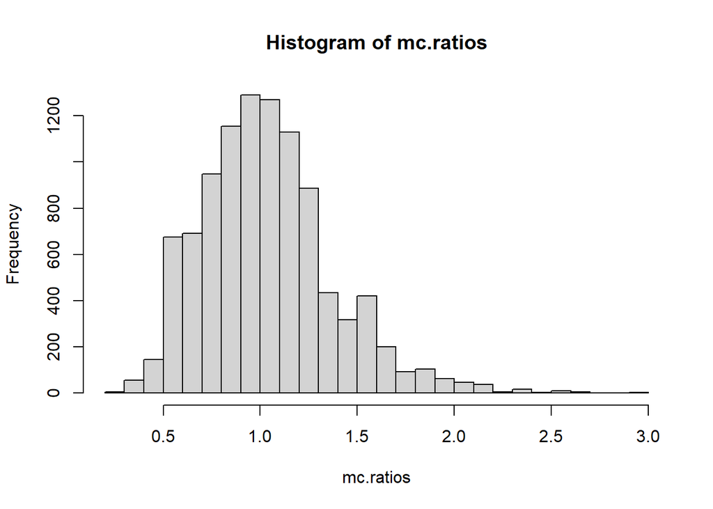

```r
hist(mc.ratios, breaks=20)
```

```r
mean(mc.ratios>=ratioFromTable(tableOfPairs(throws)))
```

```
## [1] 0.0023
```

Now we can see our original ratio of $R=2.4$ seems extremely unlikely! In particular, most of the shuffled statistics are centered around 1 (which is what we expect, since we established $R=1$ for independent sequences).

This method (which is a little more refined than the simpler run length method) appears to show that our original sequence isn’t well explained by the throws being independent. Since $R=2.4\gg1$ and this result appears unlikely to happen under independence, we may conclude **the player does actually have hot hands**.

## Permutation test: Drug Trials (Extended)

Apologies- this part of the document is a little messy, I have to remove duplicate work!

The results from a medical trial; larger numbers are “better” We want to know if there is evidence that the drug (treatment group) performs on average better than control.

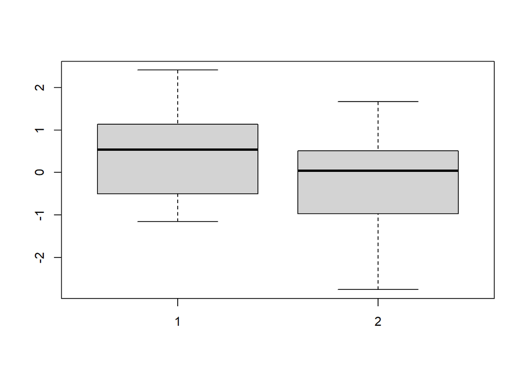

```r
control <- c(-0.10, -0.55, 1.24, -0.97, -0.76,  0.21,-0.27, -1.02, 0.58, 1.67, -1.07, 0.17, 1.45, 0.34, 1.15, 0.18, -0.97, 0.43, -1.39, -2.76 );

treatment <- c( 0.54, 0.36, 0.59, -0.57, 0.53, -0.78, -0.44, -0.98, 1.31, 0.50, 0.57, 0.49, -0.96, 2.41, 0.85, 1.93, 0.95, 1.45, 1.61, -1.16 );

boxplot(treatment, control)
```

Think about the logic of how a monte carlo test would work. We need to come up with a null model corresponding with the null hypothesis - but we really should be clear about the hypothesis that we’re testing.

Claim (alt hypothesis) - the drug works. Null hypothesis - the drug does not work.

The null model implies - these 40 values just happened to be partitioned randomly into control group and treatment group.

So in a Monte Carlo simulation, we can take these 40 values, shuffle them around, and re-partition them into “control” and “Treatment”

The second important decision we have to make: on each simulation of the data we need to calculate some statistic or number - some function of the data - that captures the… unusualness of it somehow. Something that would lend evidence towards the alt. hypothesis.

The alt hypothesis (“the drug works”) - evidence in support of this would be: the mean for the treatment group > the mean for the control group.

One idea: Our test statistic could be “TRUE/FALSE is the mean_Trt > mean_Cntrl”

```r
#Create a test_statistic function
testStat <- function(dataA, dataB){

  #true if mean dataA > mean dataB
  #return(mean(dataA) > mean(dataB))
  #Oops that doesn't work well, because it's only TRUE or FALSE

  return(mean(dataA)-mean(dataB))
}
```

Now let’s get the test statistic for the observed data:

```r
testStat(treatment, control)
```

```
## [1] 0.582
```

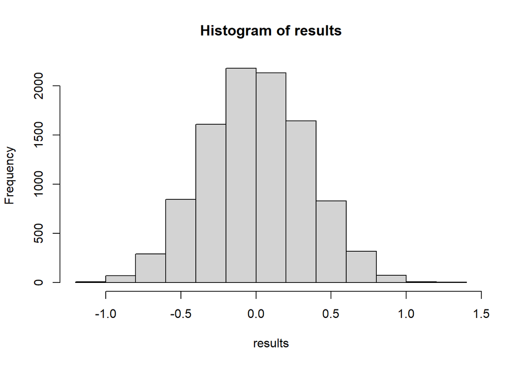

```r
#MC simulation
NMC <- 10000
results <- FALSE
for(i in 1:NMC){
  #We need to re-partition the data into two groups.
  combinedData <- c(treatment, control)
  #we next get 'simulated' treatment and control data
  shuffledData<- sample(combinedData)
  treatmentSim <- shuffledData[1:length(treatment)]
  controlSim <- shuffledData[-(1:length(treatment))]
  results[i] <- testStat(treatmentSim, controlSim)
}
hist(results)
```

```r
#Recall the alternative hypothesis:
# The drug works
# We only would consider evidence of this if the meanT-meanC >0
# So we only are going to calculate a p-value from the upper-tail
# of the distribution.

mean(results >= testStat(treatment, control))
```

```
## [1] 0.0445
```

It might be interesting to check what a parametric T test would give us.

```r
t.test(treatment, control, var.equal=TRUE, alternative="greater")
```

```
##
##  Two Sample t-test
##
## data:  treatment and control
## t = 1.7437, df = 38, p-value = 0.04465
## alternative hypothesis: true difference in means is greater than 0
## 95 percent confidence interval:
##  0.01928295        Inf
## sample estimates:
## mean of x mean of y
##     0.460    -0.122
```

Some other test statistics we could possibly use:

- difference of the medians
- difference of the max values

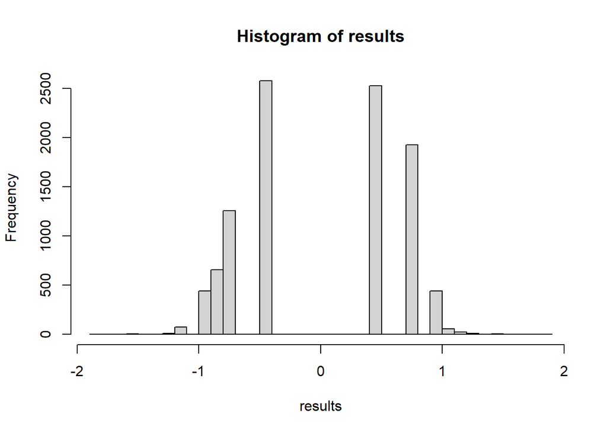

```r
#Create a test_statistic function
testStat <- function(dataA, dataB){
  return(max(dataA)-max(dataB))
}

permute_and_compute <- function( treatment, control ){
    combinedData <- c(treatment, control)
    shuffledData<- sample(combinedData)
    treatmentSim <- shuffledData[1:length(treatment)]
    controlSim <- shuffledData[-(1:length(treatment))]
    return(testStat(treatmentSim, controlSim))
}

NMC <- 10000
results <- FALSE
for(i in 1:NMC){
  results[i] <- permute_and_compute(treatment, control)
}

hist(results, breaks=50)
```

```r
mean(results >= testStat(treatment, control))
```

```
## [1] 0.2461
```

What if we use a different test statistic? Let’s compare the medians.

```r
testStat <- function(A,B){
  return(median(A)-median(B))
}

#rerun comparing the sample medians
test_statistics <- 0

(Tobsd <- testStat(treatment, control))
```

```
## [1] 0.5
```

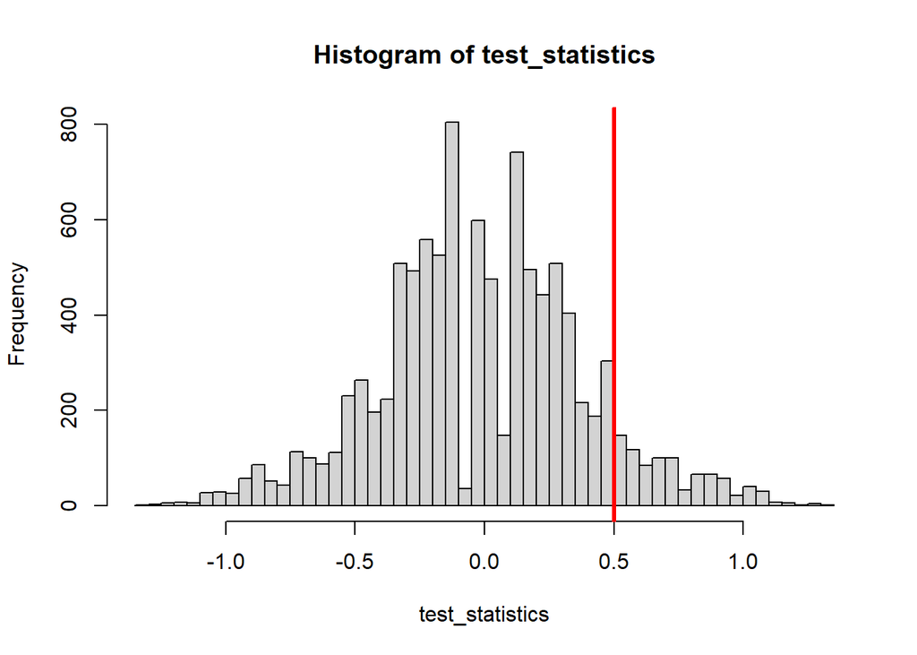

```r
for(i in 1:NMC ) {
  test_statistics[i] <- permute_and_compute( treatment, control );
}
hist( test_statistics, breaks=60 )
abline( v=Tobsd, lw=3, col='red' )
```

```r
sum(test_statistics >= Tobsd)/NMC
```

```
## [1] 0.0912
```

Let’s use KS test statistics - the max deviance between their empirical distributions!=

what is that?

```r
compare <- function(x, y) {
  n <- length(x); m <- length(y)
  w <- c(x, y)
  o <- order(w)
  z <- cumsum(ifelse(o <= n, m, -n))
  i <- which.max(abs(z))
  w[o[i]]
}
u<-compare(treatment, control) #this is where the max difference occurs
abs(mean(treatment < u) - mean(control < u))
```

```
## [1] 0.35
```

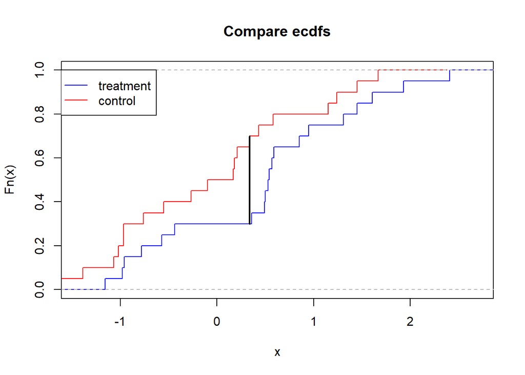

```r
ecdf1 <- ecdf(treatment)
ecdf2 <- ecdf(control)
plot(ecdf1, verticals=TRUE, do.points=FALSE, col="blue", main="Compare ecdfs")
plot(ecdf2, verticals=TRUE, do.points=FALSE, add=TRUE, col='red')
lines(c(u,u), c(ecdf1(u), ecdf2(u)), lwd=2)
legend(x=min(control,treatment), y=1, legend=c("treatment","control"), col=c("blue","red"), lty=1, xjust=-1)
```

We can pull this out from the built-in `ks.test` function. The test statistic is the max deviance between the two empirical CDFs

```r
testStat <- function(A,B){
  return(as.numeric(ks.test(A,B)[1]))
}
testStat(treatment, control)
```

```
## [1] 0.4
```

```r
#rerun

(Tobsd <- testStat(treatment, control))
```

```
## [1] 0.4
```

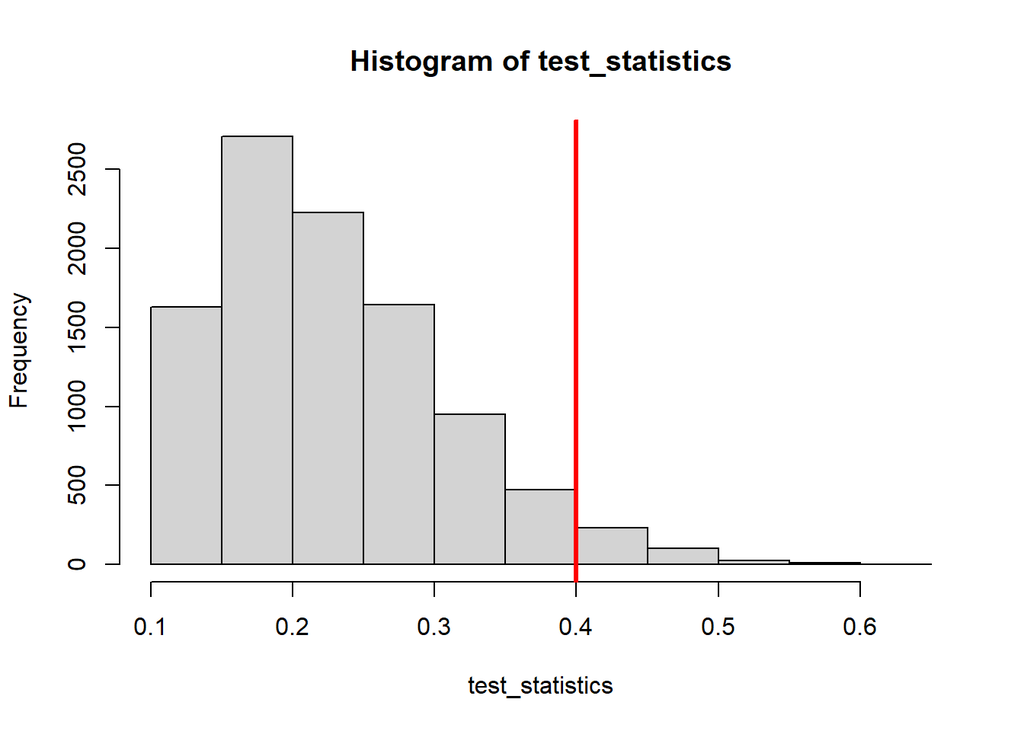

```r
test_statistics <- rep( 0, NMC ); # Vector to store our "fake" test statistics
for(i in 1:NMC ) {
  test_statistics[i] <- permute_and_compute( treatment, control );
}
hist( test_statistics )
abline( v=Tobsd, lw=3, col='red' )
```

```r
sum(test_statistics >= Tobsd)/NMC
```

```
## [1] 0.0839
```

We can spend all our time picking different test statistics, and maybe we find one that gives us a low p-value for this data set. But we have to be careful that it would generalize well to other datasets. Furthermore, we want to make sure that it would not be giving us false positives if we were comparing two populations that really did have the same distribution

- difference of means
- difference of maximums
- difference of medians
- max ecdf deviation

And we can compare them over datasets that are generated from increasingly different populations.

```r
generate_experiment <- function(nA, nB, effectSize){
  #we will assume that the values in our data are drawn from a distribution -
  #here we'll use a normal distribution. We could use permutation methods but
  #that doesn't really change the point we're trying to make.
  return(list(rnorm(nA, mean=effectSize, sd=1),
              rnorm(nB, mean=0, sd=1)))
}
#for example
generate_experiment(20,20,.5)
```

```
## [[1]]
##  [1]  0.01778166  1.65018162  1.18477818 -1.57641934 -0.64161057  0.08577461
##  [7]  1.17349869 -0.47823398 -0.26032160 -0.93443191  2.05777102 -0.84094665
## [13]  2.32726497  0.03211071  1.11730385 -0.27515971  0.35877537 -0.59002849
## [19]  0.68524808  0.39028353
##
## [[2]]
##  [1] -0.78766069  0.47220868  1.80632883 -0.50308343  1.82997227 -1.65046780
##  [7]  0.18774042  1.89357611 -0.85911026  1.78447769 -0.06779853 -0.42485180
## [13] -1.36963966  0.95244591  0.30041995 -0.57886123 -0.35174480 -1.13007872
## [19]  0.49605029  1.07811514
```

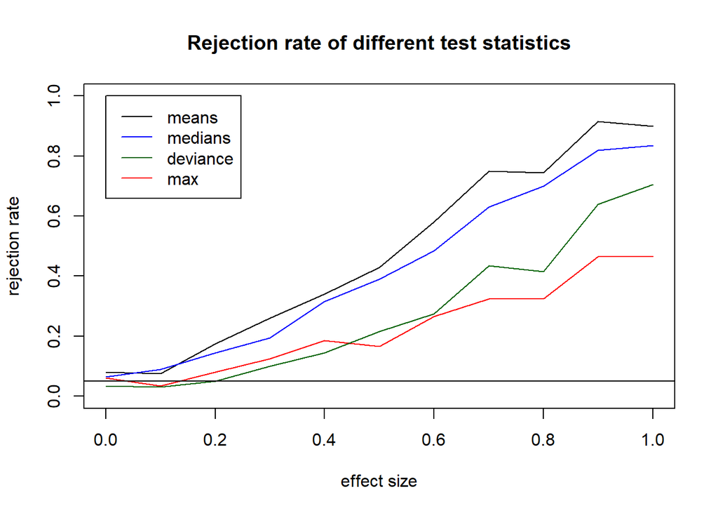

```r
nDatasets <- 200
NMC <- 200
set.seed(1)
effects <- seq(0,1,.1)
rr.mean <- 0; rr.max <- 0; rr.median <-0; rr.ks <- 0
for(k in 1:length(effects)){
  effect <- effects[k]
  rej.mean <- rep(FALSE,nDatasets)
  rej.max <- rep(FALSE,nDatasets)
  rej.median <- rep(FALSE,nDatasets)
  rej.ks <- rep(FALSE,nDatasets)
  #generate 100 different datasets
  for(j in 1:nDatasets){
    exp.data <- generate_experiment(20,20,effect)

    obs.mean <- mean(exp.data[[1]])-mean(exp.data[[2]])
    obs.median <- median(exp.data[[1]])-median(exp.data[[2]])
    obs.max <- max(exp.data[[1]])-max(exp.data[[2]])
    obs.ks <- as.numeric(ks.test(exp.data[[1]],exp.data[[2]])[1])

    #permute and compute 1000 times
    t.means <- 0
    t.medians <- 0
    t.maxes <- 0
    t.kss <- 0
    for(i in 1:NMC){
      shuffledData <- sample(c(exp.data[[1]],exp.data[[2]]))
      simA <- shuffledData[1:length(exp.data[[1]])]
      simB <- shuffledData[-(1:length(exp.data[[1]]))]

      t.means[i] <- mean(simA)-mean(simB)
      t.medians[i] <- median(simA)-median(simB)
      t.maxes[i] <- max(simA)-max(simB)
      t.kss[i] <- as.numeric(ks.test(simA,simB)[1])
    }
    rej.mean[j] <- mean(t.means >= obs.mean) <=0.05
    rej.median[j] <- mean(t.medians >= obs.median) <=0.05
    rej.max[j] <- mean(t.maxes >= obs.max) <=0.05
    rej.ks[j] <- mean(t.kss >= obs.ks) <=0.05
  }
  rr.mean[k] <- mean(rej.mean)
  rr.max[k] <- mean(rej.max)
  rr.median[k] <- mean(rej.median)
  rr.ks[k] <- mean(rej.ks)
}

plot(x=effects, y=rr.mean, type="l", ylim=c(0,1), main="Rejection rate of different test statistics", xlab="effect size", ylab="rejection rate")
lines(x=effects, y=rr.max, col="red")
lines(x=effects, y=rr.median, col="blue")
lines(x=effects, y=rr.ks, col="darkgreen")
abline(h=.05)
legend(x=0, y=1, legend=c("means","medians","deviance","max"), col=c("black","blue","darkgreen","red"), lty=1)
```

## Random number string

I want is the numbers 1 through 20 shuffled up. I ask both a computer and a person to provide me with this number string. Suppose I get the string, but I don’t know whether it came from the computer or the person.

from 2/20/2025 afternoon lecture 4 7 5 18 11 12 14 2 3 17 10 1 9 16 20 8 13 19 6 15

```r
obs.Seq <- c(4,7,5,18,11,12,14,2,3,17,10,1,9,16,20,8,13,19,6,15)
```

$H_0:$ data generated truly randomly $H_A:$ data generated by humans, not randomly, but attempted

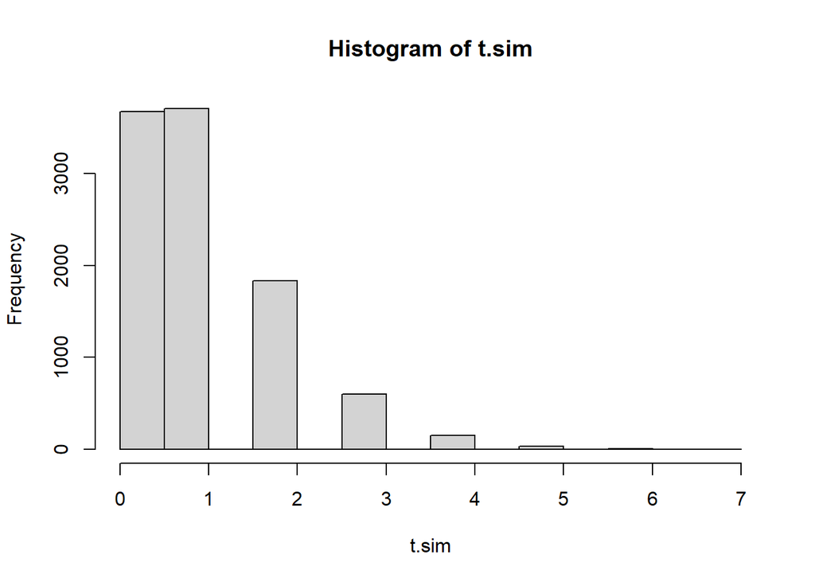

```r
count_moved <- function(x) {
  n <- length(x)
  sum((1:n) == x)
}

t.sim <- replicate(10000, count_moved(sample(20)))
hist(t.sim)
```

```r
mean(t.sim >= count_moved(obs.Seq))
```

```
## [1] 1
```

19, 7, 5, 4, 13, 11, 2, 12, 3, 1, 15, 10, 18, 16, 9, 17, 20, 14, 6, 8

(generated 9/26: 1 6 18 12 15 19 20 5 2 17 11 3 9 16 4 7 8 10 13 14)

How can I use a permutation test to determine the likely source of this string of numbers???? Said more precisely, is there evidence that sequence came from a human (not a true randomizer). The idea here is that humans are actually not great at mentally randomizing. We put patterns into things subconsciously.

```r
numbers.obs <- c(19, 7, 5, 4, 13, 11, 2, 12, 3, 1, 15, 10, 18, 16, 9, 17, 20, 14, 6, 8)
#We need a way to generate a random shuffling of the numbers

generate_numbers <- function(n.numbers){
  return(sample(n.numbers))
}
```

We also need some statistic or measurement of our data which indicates the weirdness of it. Let’s think about what wouldn’t be random.

1, 2, 3, 4, 5, 6, 7, 8, 9, 10, 11, 12, 13, 14, 15, 16, 17, 18, 19, 20

An increasing sequence of integers is very much not random. We can quantify this by counting how many differences are positive. In a random shuffling we would have some decreases and some increases. So let’s start with that statistic: The number of positive differences.

### Mean Absolute deviation

We can look at the distance of each digit from where it “started” from. Rather than just averaging all of their deviations (which would have positive deviations cancelling out with negative deviations) we can look at absolute deviations (absolute values).

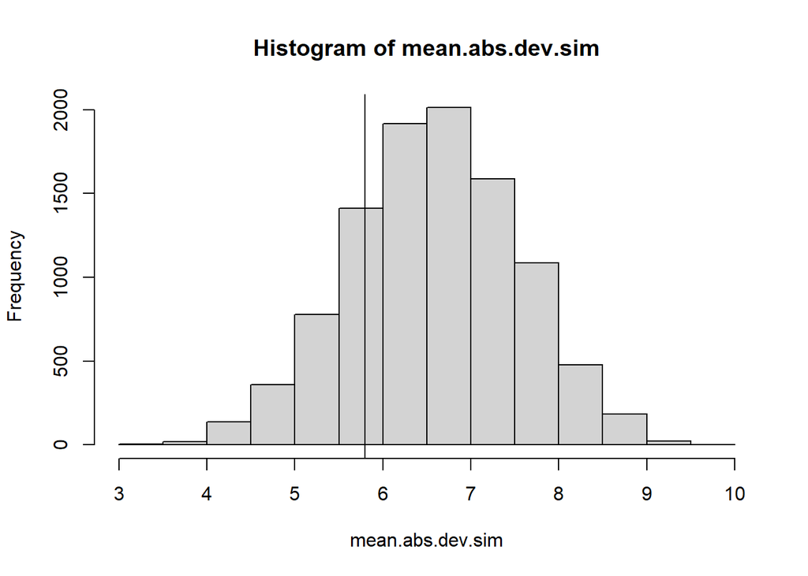

```r
mean_abs_dev <- function(x){
  n <- length(x)
  return (mean(abs(x - 1:n)))
}

t.obs <- mean_abs_dev(obs.Seq)

set.seed(1)
mean.abs.dev.sim <- replicate(10000, mean_abs_dev(generate_numbers(20)))
hist(mean.abs.dev.sim)
abline(v=t.obs)
```

```r
#2 tail p-value
2 * min(mean(mean.abs.dev.sim <= t.obs), mean(mean.abs.dev.sim >= t.obs))
```

```
## [1] 0.4122
```

### Number of positive differences

In an ordered sequence the difference between every pair of consecitive digits is +1 or -1. We could count how many (out of n-1) of the differences are positive. If the number of positive differences is too high OR too low we would suspect non-randomness; this is a two-tailed test.

```r
count_pos_diff <- function(numbers){
 return(sum(diff(numbers)>0 ))
}

count_pos_diff(numbers.obs)
```

```
## [1] 7
```

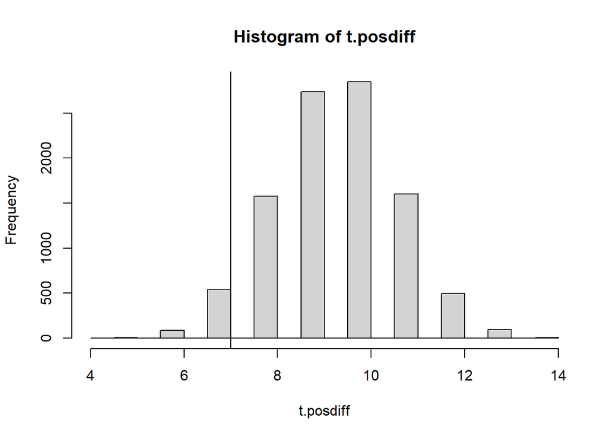

```r
NMC <- 10000
set.seed(1)
t.posdiff <- 0
for(i in 1:NMC){
  t.posdiff[i] <- count_pos_diff(generate_numbers(20))
}
hist(t.posdiff)
abline(v=count_pos_diff(numbers.obs))
```

```r
(p.val <- 2*min(
  mean(t.posdiff <= count_pos_diff(numbers.obs)),
  mean(t.posdiff >= count_pos_diff(numbers.obs))
))
```

```
## [1] 0.1278
```

Drawback of this distribution we see is that it is discrete. I’m not a big fan of discrete distributions because they can be sensitive to just a single data value, and the p-value you get increases in big jumps as you move through the distribution.

If looking only at number of positive differences we don’t see an unusually large (or unusually small) number of positive difference. No evidence of randomness. However look at this dataset:

1, 3, 2, 5, 4, 7, 6, 9, 8, 11, 10, 13, 12, 15, 14, 17, 16, 19, 18, 20

```r
count_pos_diff(c(1, 3, 2, 5, 4, 7, 6, 9, 8, 11, 10, 13, 12, 15, 14, 17, 16, 19, 18, 20))
```

```
## [1] 10
```

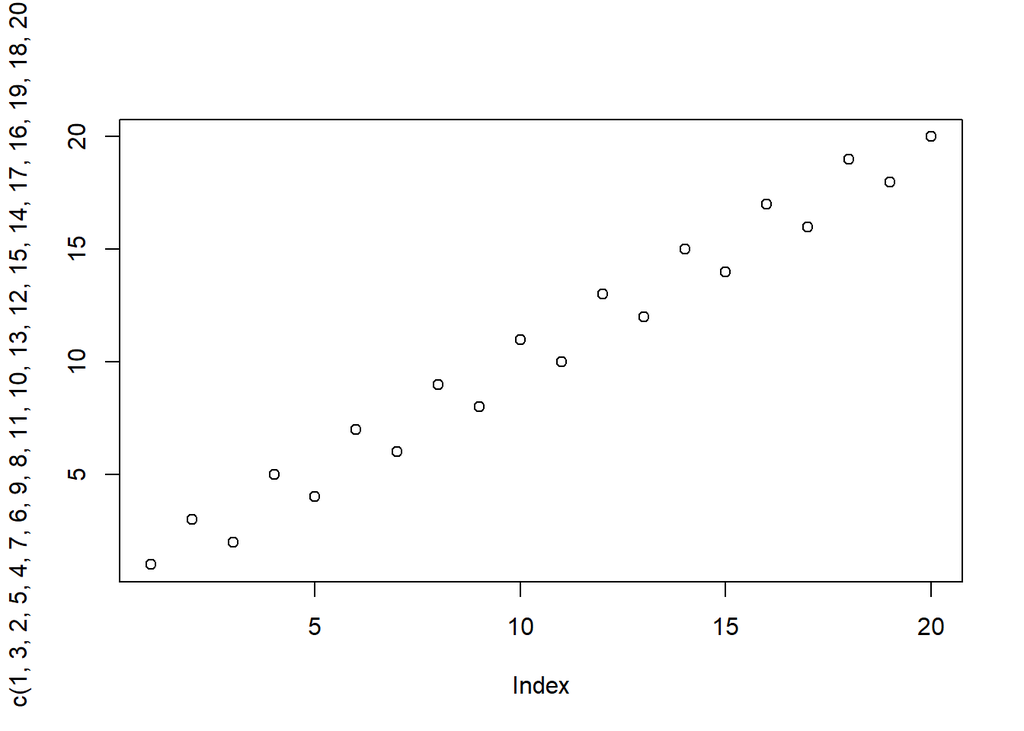

```r
plot(c(1, 3, 2, 5, 4, 7, 6, 9, 8, 11, 10, 13, 12, 15, 14, 17, 16, 19, 18, 20))
```

It’s very close to the middle of the distribution, but it’s a clear pattern. So the SIZE of the differences is clearly meaningful. We would want the differences to have the right amount of variation. If we take the differences of each consecutive pair of numbers, we can look at the *standard deviation* of those differences. That might be a good statistic to use.

### Standard Deviation of Differences

Again note that this is a two-tailed test, because if the variation is too high or too low that would be evidence of non-randomness.

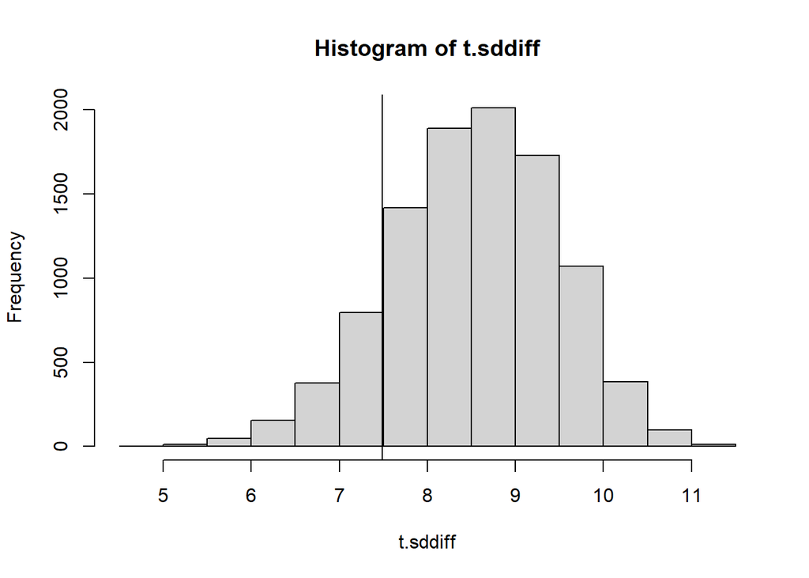

```r
calc_sd_diff <- function(numbers){
 return(sd(diff(numbers) ))
}

NMC <- 10000
set.seed(1)
t.sddiff <- 0
for(i in 1:NMC){
  t.sddiff[i] <- calc_sd_diff(generate_numbers(20))
}
hist(t.sddiff)
abline(v=calc_sd_diff(numbers.obs))
```

```r
2*min(mean(t.sddiff <= calc_sd_diff(numbers.obs)),
      mean(t.sddiff >= calc_sd_diff(numbers.obs)))
```

```
## [1] 0.2702
```

### Mean absolute difference

Another statistic we could look at is related to the *absolute values* of the differences - the average absolute difference. Again- this is a two-tailed test. Too high or too low would be evidence of nonrandomness.

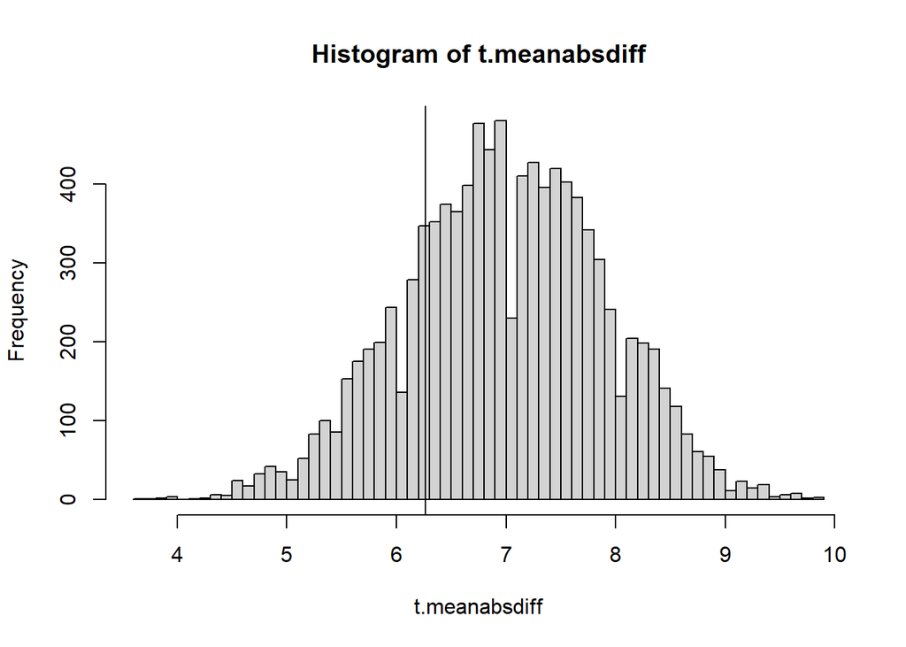

```r
calc_mean_abs_diff <- function(numbers){
 return(mean(abs(diff(numbers))))
}

NMC <- 10000
t.meanabsdiff <- 0
for(i in 1:NMC){
  t.meanabsdiff[i] <- calc_mean_abs_diff(generate_numbers(20))
}
hist(t.meanabsdiff, breaks = 50)
abline(v=calc_mean_abs_diff(numbers.obs))
```

```r
2*min(mean(t.meanabsdiff <= calc_mean_abs_diff(obs.Seq)),
      mean(t.meanabsdiff >= calc_mean_abs_diff(obs.Seq)))
```

```
## [1] 0.9274
```

No evidence of nonrandomness! We could be pretty satisfied that the string of integers was properly shuffled by a computer.

What about this one?

2 9 3 13 18 4 17 10 1 15 7 5 12 20 6 19 8 16 14 11

Do you think this was generated by computer or by human?

```r
new.obs.data<- c(2,9,3,13,18,4,17,10,1,15,7,5,12,20,6,19,8,16,14,11)

#Mean absolute deviation
2*min(mean(mean.abs.dev.sim >= mean_abs_dev(new.obs.data)),
    mean(mean.abs.dev.sim <= mean_abs_dev(new.obs.data)))
```

```
## [1] 0.3034
```

```r
#Positive Differences
2*min(mean(t.posdiff >= count_pos_diff(new.obs.data)),
    mean(t.posdiff <= count_pos_diff(new.obs.data)))
```

```
## [1] 0.9904
```

```r
#SD Differences
2*min(mean(t.sddiff >= calc_sd_diff(new.obs.data)),
    mean(t.sddiff <= calc_sd_diff(new.obs.data)))
```

```
## [1] 0.2834
```

```r
#Mean Abs Differences
2*min(mean(t.meanabsdiff >= calc_mean_abs_diff(new.obs.data)),
    mean(t.meanabsdiff <= calc_mean_abs_diff(new.obs.data)))
```

```
## [1] 0.104
```

### Comparing The Test Statistics

I want to compare the power of the test statistics as the randomness of an array increases. In order to do this we would have to have a sense of an “effect size” and look at rejection rates as effect size increases - as the vector gets more and more shuffled.

```r
popOnce <- function(x){
  #pops a random element to the top of the list
  ridx <- sample(length(x),1)
  return(c(x[-ridx],x[ridx]))
}
```

Then the `shuffleN` function takes the numbers in a vector `x` and calls the `popOnce` function `n` times.

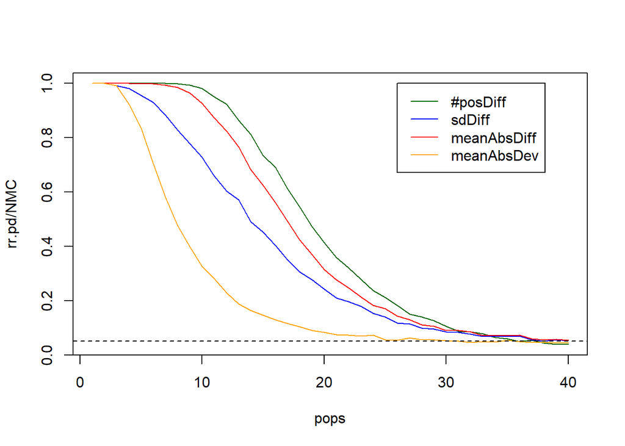

```r
shuffleN <- function(x,n=1){
  for(i in 1:n){
    x <- popOnce(x)
  }
  return(x)
}

maxPops <- 40
pops <- 1:maxPops
rr.madev <- rep(0, maxPops)
rr.pd <- rep(0,maxPops)
rr.sdd <- rep(0,maxPops)
rr.mad <- rep(0,maxPops)
NMC <- 5000

for(k in pops){
  for(i in 1:NMC){
     shuffledData <- shuffleN(1:20,k)
        #Absolute Deviation
        rr.madev[k] <- rr.madev[k] + (2*min(mean(mean.abs.dev.sim >= mean_abs_dev(shuffledData)),
            mean(mean.abs.dev.sim <= mean_abs_dev(shuffledData))) <=0.05 )
        #Positive Differences
        rr.pd[k] <- rr.pd[k] + (2*min(mean(t.posdiff >= count_pos_diff(shuffledData)),
            mean(t.posdiff <= count_pos_diff(shuffledData))) <=0.05 )
        #SD Differences
        rr.sdd[k] <- rr.sdd[k] + (2*min(mean(t.sddiff >= calc_sd_diff(shuffledData)),
            mean(t.sddiff <= calc_sd_diff(shuffledData))) <= 0.05)
        #Mean Abs Differences
        rr.mad[k] <- rr.mad[k] + (2*min(mean(t.meanabsdiff >= calc_mean_abs_diff(shuffledData)),
            mean(t.meanabsdiff <= calc_mean_abs_diff(shuffledData))) <=0.05)
  }
}
plot(pops, rr.pd/NMC, type="l", col="darkgreen")
lines(pops, rr.sdd/NMC, col="blue")
lines(pops, rr.mad/NMC, col="red")
lines(pops, rr.madev/NMC, col="orange")
legend(col=c("darkgreen","blue","red", "orange"), x=maxPops*.65, y=1, legend=c("#posDiff","sdDiff","meanAbsDiff", "meanAbsDev"), lty=1)
abline(h=0.05, lty=2)
```

From this plot it seems that the number of positive differences in the sequence is the most powerful test statistic to detect a non-randomized list. BUt of course, this is only if “non-randomized” is measured in the way we’ve defined in terms of the “effect size”.

## Random Visual Noise detection

Suppose we see an image on a monitor and want to determine if it is just random noise or if there is a pattern. Maybe this is data from a transmission from deep space. Is it just random noise, or is it possibly a message from an intelligent alien species?

For simplicity let’s say it is black/white pixels in a 16x16 grid:

```r
obsData <- matrix(
           c(0,0,0,1,1,1,0,1,1,1,0,1,1,0,0,1,
             1,1,0,1,0,1,0,0,0,0,1,1,0,1,0,1,
             0,0,1,1,0,1,0,1,1,0,1,1,0,1,0,1,
             0,0,1,0,1,1,0,1,1,1,0,0,0,1,0,1,
             1,1,1,1,0,1,1,1,0,1,1,1,1,0,0,1,
             1,0,0,0,0,1,1,1,1,1,0,0,1,1,1,0,
             1,0,1,0,1,0,0,0,1,1,0,0,0,1,0,1,
             0,1,1,0,1,0,0,0,1,1,1,1,0,1,1,1,
             0,0,1,1,1,1,1,0,0,0,1,0,1,1,1,0,
             0,0,1,1,0,0,0,1,0,1,1,0,1,1,1,1,
             0,1,1,1,1,1,1,0,1,1,1,1,1,0,1,1,
             1,0,0,1,1,0,0,1,0,0,1,0,0,1,0,0,
             0,1,0,1,1,1,1,1,0,1,1,0,1,1,0,0,
             1,0,1,0,1,0,0,0,0,1,0,1,1,1,1,1,
             1,0,0,0,0,1,0,0,1,0,0,0,0,1,1,0,
             0,1,1,1,0,1,1,0,1,1,0,1,0,1,0,1),
           nrow=16,byrow=TRUE)
par(pty="s")
require(raster)
```

[figure not shown]

```r
image(obsData, useRaster=TRUE, axes=FALSE, col=c("black","white"))
```

We want to devise a hypothesis test that will test for randomness. What can we use? Let’s look at some summary stats.

### Test Stat 1: variability in number of 1s per region

Idea: Slice it into 4x4 chunks, and count the number of 1s, then calculate the standard deviation. If we have random noise data then we should have some variability in each of these 16 sub-squares.

```r
sd_chunk_1s <- function(matrix){
  #I will assume that the data is 16x16. This function is not going to
  #generalize well to other sized inputs.
  results <- numeric(0)
  for(i in seq(1,15, 4)){
    for(j in seq(1,15, 4)){
      chunk <- matrix[i:(i+3), j:(j+3)]
      results <- rbind(results, sum(chunk))
    }
  }
  return(sd(results))
}
sd_chunk_1s(obsData)
```

```
## [1] 1.181454
```

We can perform our permutation test, randomizing the grid and calculating the test statistic on each run.

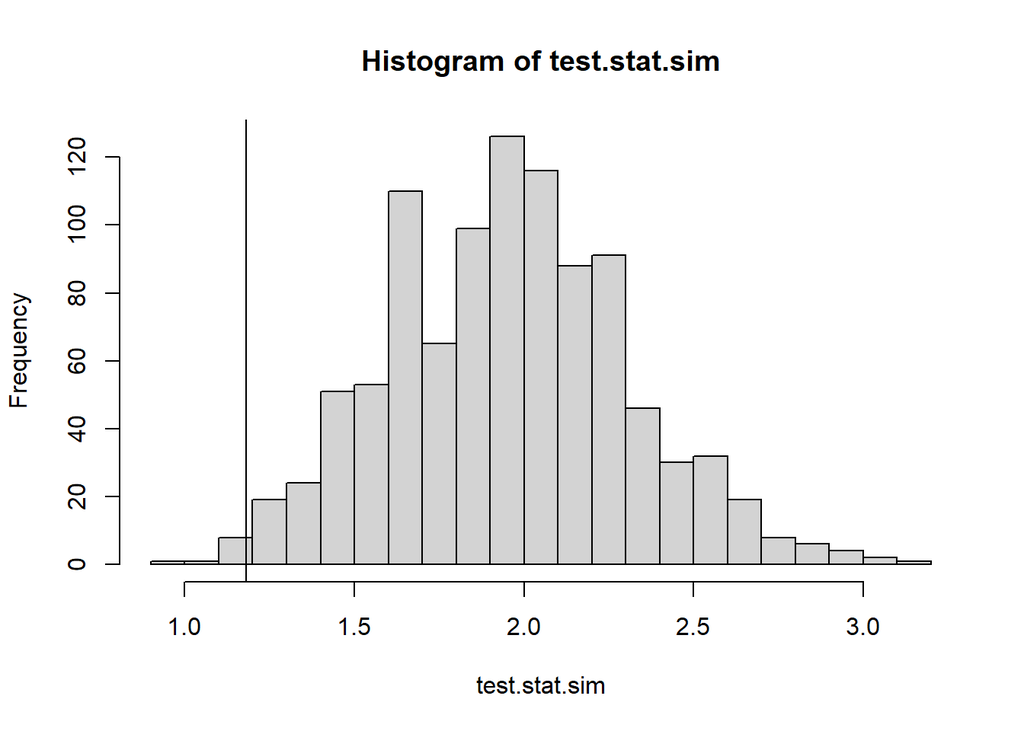

```r
#Permutation test
test.stat.sim <- 0
for(i in 1:1000){
  test.stat.sim[i] <- sd_chunk_1s(matrix(data=sample(obsData), nrow=dim(obsData)[1], byrow=TRUE))
}
hist(test.stat.sim, breaks=25)
abline(v=sd_chunk_1s(obsData))
```

```r
#two tailed test, ie if sd too low or too high that is unusual
2*min(mean(test.stat.sim <= sd_chunk_1s(obsData)),
      mean(test.stat.sim >= sd_chunk_1s(obsData)))
```

```
## [1] 0.02
```

### Test Stat 2: Horizontal Symmetry

We can look at what proportion of pixels are the same as their mirror pixel. A fast way to calculate that is to compare the image with it’s flip, do a conditional comparison of values, and divide by 2.

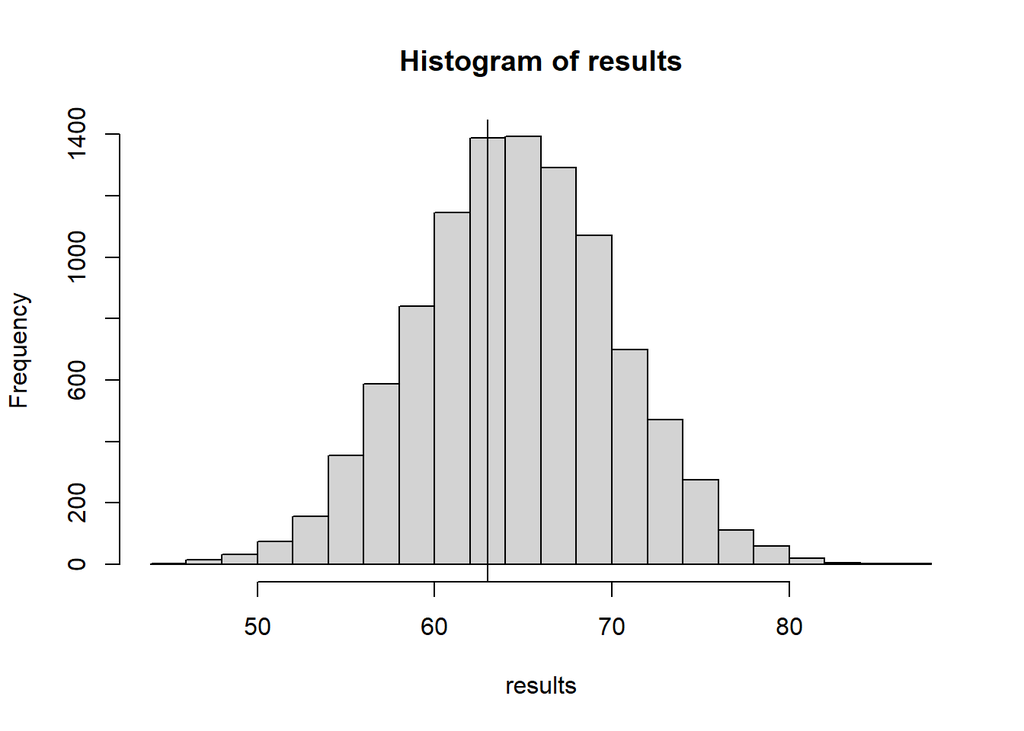

```r
calculate_horizontal_symmetry <- function(matrix){
  nCols <- dim(matrix)[2]
  matrix.flip <- matrix[,nCols:1]
  return(sum(matrix==matrix.flip)/2)
}

NMC <- 10000
results <- 0
for(i in 1:NMC){
  shuffledMatrix <- matrix(data=sample(obsData), nrow=dim(obsData)[1], byrow=TRUE)
  results[i] <- calculate_horizontal_symmetry(shuffledMatrix)
}
hist(results)
abline(v=calculate_horizontal_symmetry(obsData))
```

```r
calculate_horizontal_symmetry(obsData)
```

```
## [1] 63
```

### Test stat 3: Neighbor edges

Look at vertical neighbors (and horizontal neighbors)

A 00 edge will sum to 0 A 01 or 10 edge will sum to 1 A 11 edge will sum to 2

```r
vEdges <- obsData[-1,]+obsData[-16,]
hEdges <- obsData[,-1]+obsData[,-16]
table(vEdges)
```

```
## vEdges
##   0   1   2
##  46 121  73
```

```r
table(hEdges)
```

```
## hEdges
##   0   1   2
##  43 126  71
```

```r
#Add two tables together!
table(vEdges)+table(hEdges)
```

```
## vEdges
##   0   1   2
##  89 247 144
```

```r
#Let's let the BW edges be the test statistic to see how well it works:
count_bw_edges <- function(matrix){
  dims <- dim(matrix)
  vEdges <- matrix[-1,]+matrix[-dim(matrix)[1],]
  hEdges <- matrix[,-1]+matrix[,-dim(matrix)[2]]
  bwEdges <- as.numeric((table(factor(vEdges, levels=0:2))+
                           table(factor(hEdges, levels=0:2)))[2])
  return(bwEdges)
}

count_bw_edges(obsData)
```

```
## [1] 247
```

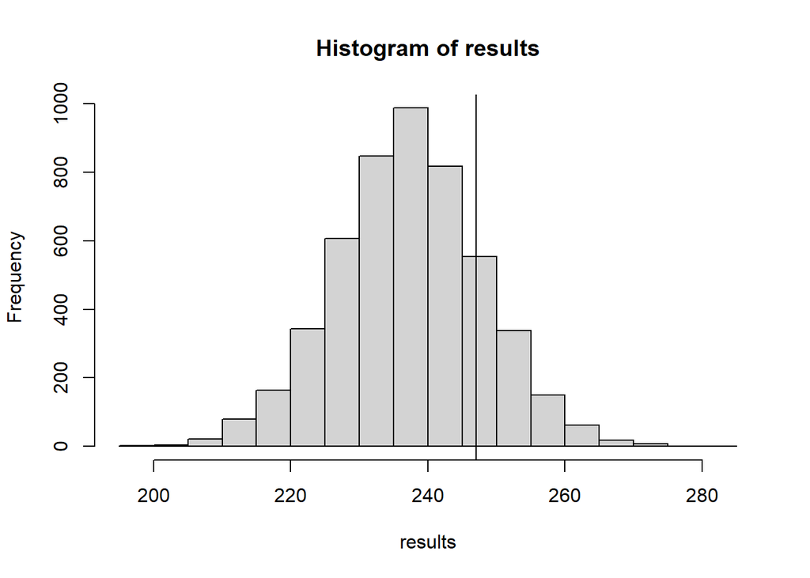

```r
NMC <- 5000
results <- 0
for(i in 1:NMC){
  shuffledMatrix <- matrix(data=sample(obsData), nrow=dim(obsData)[1], byrow=TRUE)
  results[i] <- count_bw_edges(shuffledMatrix)
}
hist(results)
abline(v=count_bw_edges(obsData))
```

This test statistic doesn’t detect all kinds of non-randomness. Let’s see how well this test statistic does against some image that is definitely not random:

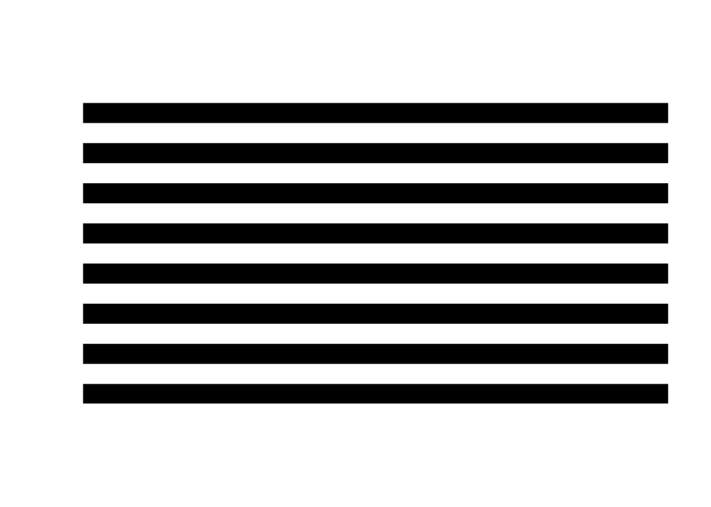

```r
obsData2 <- matrix(rep(c(0,1),8*16),nrow=16, byrow=TRUE)
image(obsData2, useRaster=TRUE, axes=FALSE, col=c("black","white"))
```

```r
par(pty="s")
count_bw_edges(obsData2)
```

```
## [1] 240
```

Or this one

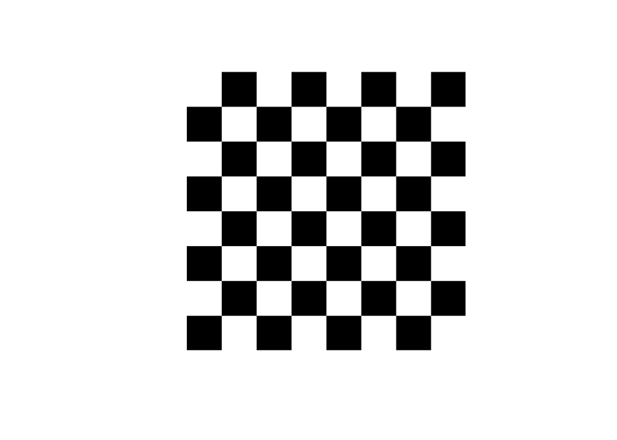

```r
obsData3 <- matrix(rep(c(rep(c(0,0,1,1),8),rep(c(1,1,0,0),8)),4), ncol=16, byrow=TRUE)
par(pty="s")
image(obsData3, useRaster=TRUE, axes=FALSE, col=c("black","white"))
```

```r
count_bw_edges(obsData3)
```

```
## [1] 224
```

Let’s just create a function to automate the MC simulation

```r
generateMCsim <- function(data, NMC){
  results <- 0
  for(i in 1:NMC){
    shuffledMatrix <- matrix(data=sample(data), nrow=dim(data)[1], byrow=TRUE)
    results[i] <- count_bw_edges(shuffledMatrix)
  }
  return(results)
}
```

And now the Monte Carlo part.

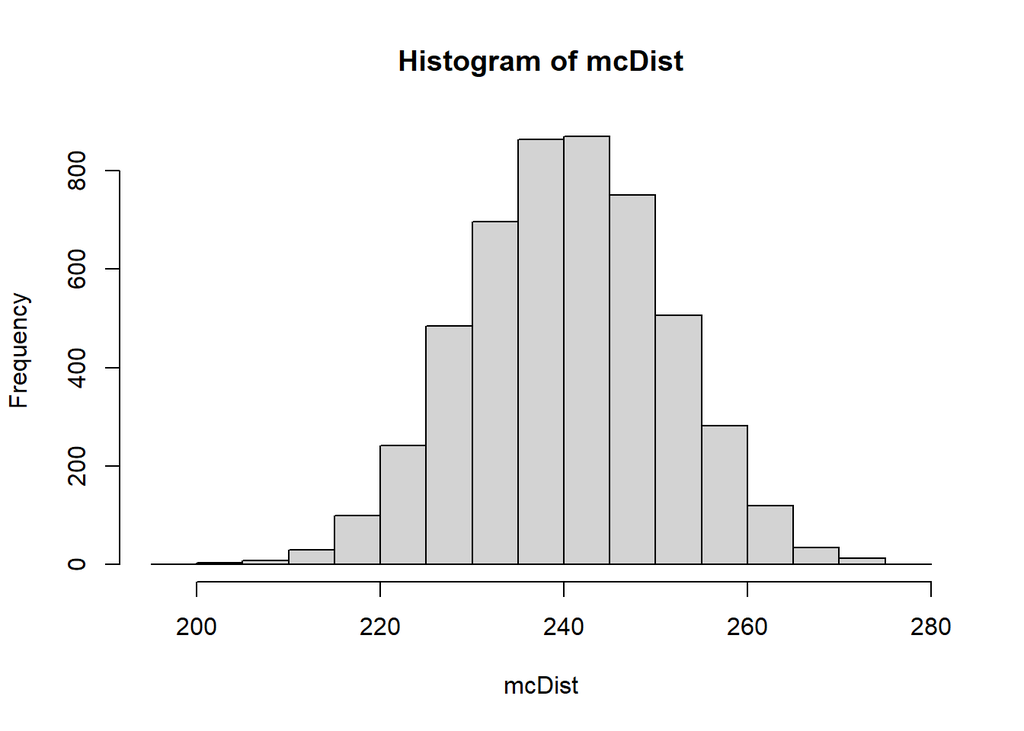

```r
mcDist <- generateMCsim(obsData2,5000)
hist(mcDist)
```

```r
count_bw_edges(obsData2)
```

```
## [1] 240
```